# Introduction to R

by Irimia Mihaela

2024-01-23

### **Test - Introduction to R**

#### **Analyzed data set:** **pirates**

Loading the necessary packages:

# *Select pirates that have at least 5 tattoos or at least 5 parrots, have ‘Jack Sparrow’ as their favorite pirate, wear a headband, have a beard length of at least 15, and what are their records ordered by ID?*

```r
selectie_pirates <- pirates %>%
  filter(tattoos >= 5 | parrots >= 5) %>%
  filter(favorite.pirate == "Jack Sparrow") %>%
  filter(headband == "yes") %>%
  filter(beard.length >= 15) %>%
  arrange(id)
selectie_pirates %>%
  head(10)
```

```
##    id  sex age height weight headband college tattoos tchests parrots
## 1   1 male  28 173.11   70.5      yes   JSSFP       9       0       0
## 2   2 male  31 209.25  105.6      yes   JSSFP       9      11       0
## 3   3 male  26 169.95   77.1      yes    CCCC      10      10       1
## 4   6 male  26 190.20   85.4      yes    CCCC       7      19       0
## 5  10 male  30 183.52   84.7      yes   JSSFP      12      69       4
## 6  12 male  20 163.65   70.0      yes    CCCC      14       5       3
## 7  14 male  26 177.99   78.2      yes    CCCC       9      12       3
## 8  17 male  21 177.52   72.7      yes    CCCC      11       3       0
## 9  20 male  26 175.45   69.0      yes    CCCC      14      30       3
## 10 24 male  12 175.29   83.0      yes    CCCC      10       3       2
##    favorite.pirate sword.type eyepatch sword.time beard.length
## 1     Jack Sparrow    cutlass        1       0.58           16
## 2     Jack Sparrow    cutlass        0       1.11           21
## 3     Jack Sparrow    cutlass        1       1.44           19
```

[output cut: 18 more lines]

# *Plot the heights and the weight of the pirates*

```r
class(pirates)
```

```
## [1] "data.frame"
```

```r
str(pirates)
```

```
## 'data.frame':    1000 obs. of  17 variables:
##  $ id             : int  1 2 3 4 5 6 7 8 9 10 ...
##  $ sex            : chr  "male" "male" "male" "female" ...
##  $ age            : num  28 31 26 31 41 26 31 31 28 30 ...
##  $ height         : num  173 209 170 144 158 ...
##  $ weight         : num  70.5 105.6 77.1 58.5 58.4 ...
##  $ headband       : chr  "yes" "yes" "yes" "no" ...
##  $ college        : chr  "JSSFP" "JSSFP" "CCCC" "JSSFP" ...
##  $ tattoos        : num  9 9 10 2 9 7 9 5 12 12 ...
##  $ tchests        : num  0 11 10 0 6 19 1 13 37 69 ...
##  $ parrots        : num  0 0 1 2 4 0 7 7 2 4 ...
##  $ favorite.pirate: chr  "Jack Sparrow" "Jack Sparrow" "Jack Sparrow" "Jack Sparrow" ...
##  $ sword.type     : chr  "cutlass" "cutlass" "cutlass" "scimitar" ...
##  $ eyepatch       : num  1 0 1 1 1 1 0 1 0 1 ...
##  $ sword.time     : num  0.58 1.11 1.44 36.11 0.11 ...
##  $ beard.length   : num  16 21 19 2 0 17 1 1 1 25 ...
##  $ fav.pixar      : chr  "Monsters, Inc." "WALL-E" "Inside Out" "Inside Out" ...
##  $ grogg          : num  11 9 7 9 14 7 9 12 16 9 ...
```

the name of the variables

```r
names(pirates)
```

```
##  [1] "id"              "sex"             "age"             "height"
##  [5] "weight"          "headband"        "college"         "tattoos"
##  [9] "tchests"         "parrots"         "favorite.pirate" "sword.type"
## [13] "eyepatch"        "sword.time"      "beard.length"    "fav.pixar"
## [17] "grogg"
```

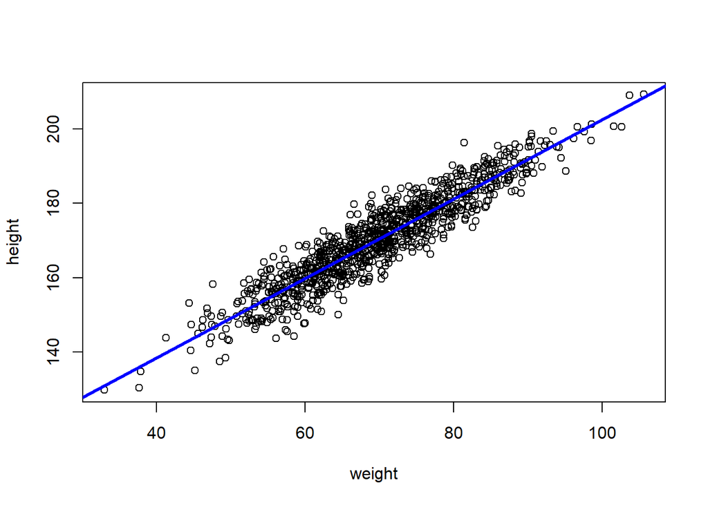

```r
plot(height ~ weight,  pirates) # the scatter plot
abline(coef(lm(height ~ weight, pirates)), col = 'blue', lwd = 3) # the regression line
```

as we can see the relationship between weight and heights variables is linear

# *Test if there is a difference between pirates with eye patch and those without eye patch*

first we will test if the variance of the pirates with eye patch and that of the pirates without eye patch is equal or not

checking the type of eye patch variable

```r
levels(pirates$eyepatch)
```

```r
pirates$eyepatch <- as.factor(pirates$eyepatch)
```

setting the first group: pirates without eye patch

```r
levels(pirates$eyepatch) <- c('fara_petec', 'cu_petec')
```

testing the variance with Bartlett test

```r
bartlett.test(beard.length~eyepatch, pirates, eyepatch %in%  c('fara_petec', 'cu_petec'))
```

```
##
##  Bartlett test of homogeneity of variances
##
## data:  beard.length by eyepatch
## Bartlett's K-squared = 0.34336, df = 1, p-value = 0.5579
```

or

```r
bartlett.test(beard.length~eyepatch, pirates)
```

```
##
##  Bartlett test of homogeneity of variances
##
## data:  beard.length by eyepatch
## Bartlett's K-squared = 0.34336, df = 1, p-value = 0.5579
```

Hypothesis:

$$H_0: \text{The variances of the groups are equal}$$

$$H_1: \text{The variance of the groups is significantly different}$$

Decision:
$$p\text{-value} < 0.05 \Rightarrow \text{we reject } H_0 \text{ with a
5\% risk of Type I error}$$
$$p\text{-value} \ge 0.05 \Rightarrow \text{fail to reject } H_0 \text{ at
the 5\% significance level}$$
Results
$$p\text{-value} = 0.5579 > 0.05 \Rightarrow \text{fail to reject } H_0$$

The variance between the groups is not statistically significant.

Second we will test if there is a difference between pirates with eye patch and those without eye patch we use the t test for independent samples

```r
t.test(beard.length~eyepatch, data = pirates, alternative = 'greater', var.equal=T)
```

```
##
##  Two Sample t-test
##
## data:  beard.length by eyepatch
## t = 1.453, df = 998, p-value = 0.07326
## alternative hypothesis: true difference in means between group fara_petec and group cu_petec is greater than 0
## 95 percent confidence interval:
##  -0.1328453        Inf
## sample estimates:
## mean in group fara_petec   mean in group cu_petec
##                 11.04094                 10.04255
```

Hypothesis

Used test: t test

Results:

$${\text{ p-value = 0.07326 > 0,05
=> accepting H_0. There is no significant differences between the
analyzed groups }}$$

# *Checking the code for errors*

Can we compare the models?

```r
ms1<-lm(pirates$beard.length~pirates$height)
ms2<-lm(pirates$beard.length~pirates$weight+I(pirates$weight^2))
```

The models can not be compare, because the independent variables are not the same

```r
anova(ms1, ms2)
```

```
## Analysis of Variance Table
##
## Model 1: pirates$beard.length ~ pirates$height
## Model 2: pirates$beard.length ~ pirates$weight + I(pirates$weight^2)
##   Res.Df   RSS Df Sum of Sq F Pr(>F)
## 1    998 81169
## 2    997 83450  1   -2281.5
```

the value of the p-value is missing

```r
ms1<-lm(pirates$beard.length~pirates$height)
ms2<-lm(pirates$beard.length~pirates$height+I(pirates$height^2))
```

to be able to compere the two models the weight variable must be replace with height variable

```r
anova(ms1, ms2)
```

```
## Analysis of Variance Table
##
## Model 1: pirates$beard.length ~ pirates$height
## Model 2: pirates$beard.length ~ pirates$height + I(pirates$height^2)
##   Res.Df   RSS Df Sum of Sq      F Pr(>F)
## 1    998 81169
## 2    997 80995  1    173.89 2.1405 0.1438
```

$$H_0: \text{There is no difference between the models}$$

$$H_1: \text{The complex model is better than the simple regression model
}$$
$$p\text{-value} = 0.1438 > 0.05 \Rightarrow \text{fail to reject }
H_0.$$

There is no statistically significant difference between the models.

# *Transform a numerical variable into a variable with 3 classes*

```r
str(pirates)
```

```
## 'data.frame':    1000 obs. of  17 variables:
##  $ id             : int  1 2 3 4 5 6 7 8 9 10 ...
##  $ sex            : chr  "male" "male" "male" "female" ...
##  $ age            : num  28 31 26 31 41 26 31 31 28 30 ...
##  $ height         : num  173 209 170 144 158 ...
##  $ weight         : num  70.5 105.6 77.1 58.5 58.4 ...
##  $ headband       : chr  "yes" "yes" "yes" "no" ...
##  $ college        : chr  "JSSFP" "JSSFP" "CCCC" "JSSFP" ...
##  $ tattoos        : num  9 9 10 2 9 7 9 5 12 12 ...
##  $ tchests        : num  0 11 10 0 6 19 1 13 37 69 ...
##  $ parrots        : num  0 0 1 2 4 0 7 7 2 4 ...
##  $ favorite.pirate: chr  "Jack Sparrow" "Jack Sparrow" "Jack Sparrow" "Jack Sparrow" ...
##  $ sword.type     : chr  "cutlass" "cutlass" "cutlass" "scimitar" ...
##  $ eyepatch       : Factor w/ 2 levels "fara_petec","cu_petec": 2 1 2 2 2 2 1 2 1 2 ...
##  $ sword.time     : num  0.58 1.11 1.44 36.11 0.11 ...
##  $ beard.length   : num  16 21 19 2 0 17 1 1 1 25 ...
##  $ fav.pixar      : chr  "Monsters, Inc." "WALL-E" "Inside Out" "Inside Out" ...
##  $ grogg          : num  11 9 7 9 14 7 9 12 16 9 ...
```

```r
pirates$inaltime_cat<-cut(pirates$height, 3, c("Short", "Medium",  "Tall"))
```